# 140.653 Lab 3: Adjusted Variable Plot

Erjia Cui & Elizabeth Colantuoni

```r
library(ggplot2)
library(dplyr)
```

## 1. Adjusted variable plot

In this section we show how to make an adjusted variable plot using the Nepali anthropometry data. Our goal is to visualize the relationship between arm circumference ($Y$) and age ($X$) after adjusting for height ($Z$).

There are three steps to construct an adjusted variable plot

1. Regress arm circumference on height and obtain the residuals $R(Y|Z)$.
2. Regress age on height and obtain the residuals $R(X|Z)$.
3. Plot $R(Y|Z)$ vs $R(X|Z)$.

```r
## Preprocess the dataset
load("./../nepal.anthro.rdata")
head(nepal.anthro)
```

```
##       id sex   wt    ht  arm bf day month year mage lit died alive t2 age num
## 1 120011   1 12.8  91.2 14.3  0  15     9   46   35   0    2     5  9  41   1
## 2 120011   1 12.8  93.9 13.5  0  22     1   47   35   0    2     5 13  45   2
## 3 120011   1 13.1  95.2 14.5  0   3     5   47   35   0    2     5 17  49   3
## 4 120011   1 13.8  96.9 14.1  0   6     9   47   35   0    2     5 21  53   4
## 5 120011   1   NA    NA   NA  0  20     1   48   35   0    2     5 25  57   5
## 6 120012   2 14.9 103.9 13.9  0  15     9   46   35   0    2     5  9  57   1
##   xmin agemin agemax age_sp1 age_sp2 age_sp3 age1 age2 age3 age4   armpr1
## 1   41     41     57      29      17       0    0    0   41    0 14.15903
## 2   41     41     57      33      21       0    0    0   45    0 14.30622
## 3   41     41     57      37      25       1    0    0    0   49 14.42511
## 4   41     41     57      41      29       5    0    0    0   53 14.45913
## 5   41     41     57      45      33       9    0    0    0   57 14.49315
## 6   57     57     73      45      33       9    0    0    0   57 14.57972
##   futime fuvisit fuvisit1
## 1      1       0        0
## 2      5       1        1
## 3      9       2        2
## 4     13       3        3
## 5     17       4        4
## 6      1       0        0
```

```r
d <- nepal.anthro %>% select(names(.)[1:16]) %>% filter(.,num==1)
cc <- complete.cases(select(d,age,arm))
d.cc <- filter(d, cc)
d.cc <- arrange(d.cc,age)
```

Fit the regression models and plot the residuals. Fit a line through the residuals to show the trend.

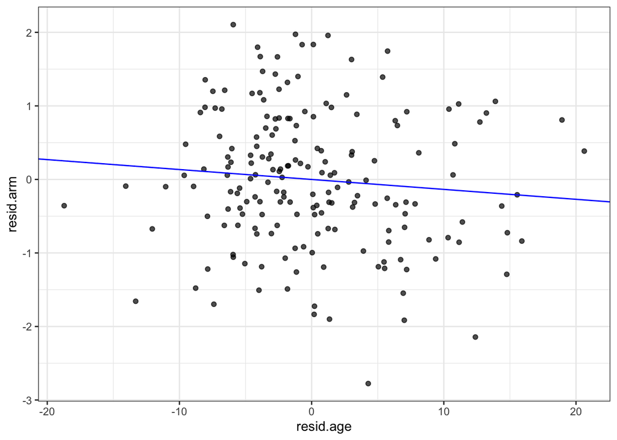

```r
d.cc$resid.arm <- lm(arm~ht,data=d.cc)$residuals
d.cc$resid.age <- lm(age~ht,data=d.cc)$residuals
resid.model <- lm(resid.arm~resid.age-1,data=d.cc)

## plot the estimates
ggplot(d.cc, aes(x=resid.age,y=resid.arm)) +
  theme_bw() +
  geom_jitter(alpha=0.7) +
  geom_abline(intercept=0,slope=coef(resid.model), color="blue")
```

What conclusions can you make?

## 2. Equivalence of adjusted variable regression and multiple linear regression.

There are two ways to estimate the relationship between age and arm circumference adjusting for height:

- Adjusted variable regression: “remove” height from arm circumference and age, then fit a regression model on the residuals.
- Multiple linear regression: add height to the multiple linear regression as a covariate.

```r
print(coef(resid.model))
```

```
##   resid.age
## -0.01352282
```

```r
mlr.model <- lm(arm~age+ht,data=d.cc)
print(coef(mlr.model)["age"])
```

```
##         age
## -0.01352282
```

The coefficients are exactly the same. Why?

### Sketch proof

In adjusted variable regression
$$Y = A_0 + A_1 Z + e_{zy}$$
$$X = C_0 + C_1 Z +e_{zx}$$
Then fit a line through the residuals without intercept (since the residuals are centered at 0)
$$Y-(A_0+A_1Z)=B_1[X-(C_0+C_1Z)]+e$$
Rearranging the terms gives
$$Y = A_0 + B_1C_0 + B_1X + (A_1+B_1C_1)Z + e$$
Rewrite the coefficients as $B_0=A_0+B_1C_0$, $B_2=A_1+B_1C_1$ and we have multiple linear regression model
$$Y = B_0 + B_1 X + B_2 Z + e$$
Hence adjusted variable regression and multiple linear regression give the same coefficient for $X$.

**The equivalence only holds when the functions and adjustments are linear.**

**This is only a sketch proof. You have to write down the analytical forms of residual to give a formal proof.**

## 3. What if we adjust for multiple covariates?

Here we create an adjusted variable plot of arm circumference versus age, adjusting for height (ht), weight (wt) and sex.

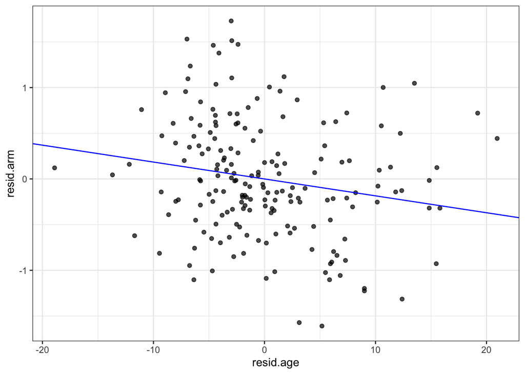

```r
d.cc$resid.arm <- lm(arm~ht+wt+sex,data=d.cc)$residuals
d.cc$resid.age <- lm(age~ht+wt+sex,data=d.cc)$residuals
resid.model <- lm(resid.arm~resid.age-1,data=d.cc)

ggplot(d.cc, aes(x=resid.age,y=resid.arm)) +
  theme_bw() +
  geom_jitter(alpha=0.7) +
  geom_abline(intercept=0,slope=coef(resid.model), color="blue")
```

```r
# Slope of adjusted variable plot
print(coef(resid.model))
```

```
##  resid.age
## -0.0185027
```

```r
# Multiple linear regression
mlr.model <- lm(arm~age+ht+wt+sex,data=d.cc)
print(coef(mlr.model)["age"])
```

```
##        age
## -0.0185027
```

What conclusions can you draw?

## Exercise 1

Using the Nepali anthropometry data, create an adjusted variable plot of weight versus age, adjusting for height (ht).

- Obtain the residuals of weight and age regressed on height.
- Plot the residuals of weight against those of age.
- Verify that adjusted variable estimate is equal to the MLR estimate.

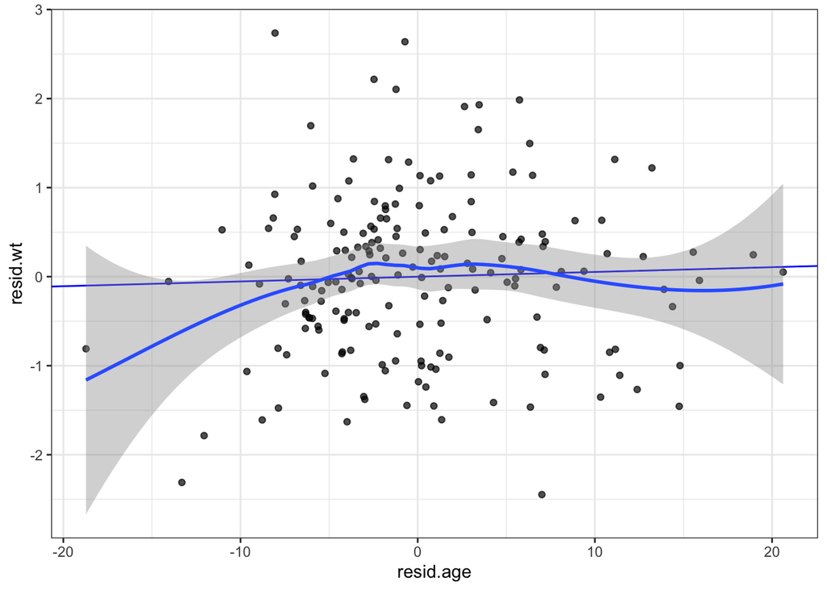

```r
d.cc$resid.wt <- lm(wt~ht,data=d.cc)$residuals
d.cc$resid.age <- lm(age~ht,data=d.cc)$residuals
resid.model <- lm(resid.wt~resid.age-1,data=d.cc)

ggplot(d.cc, aes(x=resid.age,y=resid.wt)) +
    theme_bw() +
    geom_jitter(alpha=0.7) +
    geom_abline(intercept=0,slope=coef(resid.model), color="blue") +
    geom_smooth(span=0.7)
```

```r
print(coef(resid.model))
```

```
##   resid.age
## 0.005368228
```

```r
mlr.model = lm(wt~age+ht,data=d.cc)
print(coef(mlr.model)["age"])
```

```
##         age
## 0.005368228
```

## Exercise 2

Use the observed age, weight (wt), height (ht), sex in the Nepali anthropometry data, simulate arm circumference value from different scenarios:

1. ARM = 7.8 + 0 x age + 0.03 x female + 0.07 x ht + error, error iid N(0,0.93)
2. ARM = 7.8 + 0.035 x age + 0.03 x female + 0.07 x ht + error, error iid N(0,0.93)
3. ARM = 7.8 + 0.05 x age – 0.025 x (age – 6) x (age > 6) + 0.03 x female + 0.07 x ht + error

Create an adjusted variable plot of arm circumference versus age, adjusting for height (ht) and sex.

```r
## scenario 1
d.cc$arm.s1 <- 7.8 + 0.03*d.cc$sex + 0.07*d.cc$ht + rnorm(nrow(d.cc), 0, 0.93)
## scenario 2
d.cc$arm.s2 <- 7.8 + 0.035*d.cc$age + 0.03*d.cc$sex + 0.07*d.cc$ht + rnorm(nrow(d.cc), 0, 0.93)
## scenario 3
d.cc$arm.s3 <- 7.8 + 0.05*d.cc$age - 0.025*(d.cc$age-6)*(d.cc$age > 6) + 0.03*d.cc$sex + 0.07*d.cc$ht + rnorm(nrow(d.cc), 0, 0.93)
```